# Day 4 - Statistical Analysis using R

2017-08-31

# Introduction

In this lab we will introduce functions used for basic statistical analysis

### Student Learning Objectives

After completing this lesson students will be able to identify a handful of functions to perform statistical analysis techniques using R

**Note: This lesson does not cover the Statistical Methodology or theory behind these statistical procedures. This workshop assumes that you have checked model assumptions and have chosen the most appropriate model for the research question being analyzed.**

# Prepare for class

1. Download the `cdc` data from this link and store it in your class folder.
   - Don’t forget to right click and *save link as*.
2. Download this RMD file that was used to create this lesson.
   - Prepare to write your own notes in it during class. There will be nothing to turn in.
3. Install the `ggplot2` and `gridExtra` packages into R if you have not already done so.
   - We will learn more how these functions work to create graphics next week.

## About the Data

The data comes from the Center for Disease Control (CDC), which has been conducting the Behavioral Risk Ractor Surveillance System (BRFSS) since 1984. BRFSS is the nation’s premier system of health-related telephone surveys that collect state data about U.S. residents regarding their health-related risk behaviors, chronic health conditions, and use of preventive services. The data we are using comes from a random sample of 20,000 participants from this survey. More information on the survey and data can be found at https://www.cdc.gov/brfss/

# In class

Setup your first code chunk to load libraries, set options, and read in the data.

```r
knitr::opts_chunk$set(echo = TRUE)
library(ggplot2)
library(gridExtra)
cdc <- read.table("../data/cdc.txt", header=TRUE, sep="\t")
```

## Data Management / cleaning

Let’s create some variables that we’ll analyze throughout this tutorial.

The BEFSS asks participants how much they weigh, and how much they want to weigh. Let’s create a difference between the two to measure whether the participants feel the are under, or overweight. **Create the variable `wtdiff` as `wtdesire` - `weight`, so a positive value means they want to gain weight.**

```r
cdc$wtdiff <- cdc$wtdesire - cdc$weight
```

## Simple Analysis

```r
library(ggplot2)
library(gridExtra)

# Optional settings for cleaning up the resulting knitted document
library(knitr)
opts_chunk$set(warning=FALSE, message=FALSE,
               fig.align = 'center',  fig.width=6, fig.height=4)
```

### One sample T-test for a mean

**Are people on average happy with their weight?**

1. Look at your data. Calculate summary statistics and a plot.

```r
summary(cdc$wtdiff)
```

```
##    Min. 1st Qu.  Median    Mean 3rd Qu.    Max.
## -300.00  -21.00  -10.00  -14.59    0.00  500.00
```

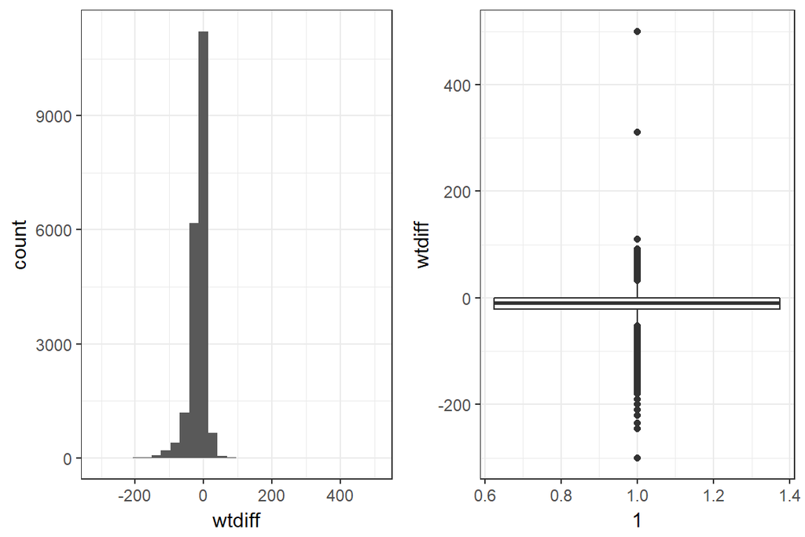

```r
a <- ggplot(cdc, aes(x=wtdiff)) + geom_histogram() + theme_bw()
b <- ggplot(cdc, aes(x=1, y=wtdiff)) + geom_boxplot() + theme_bw()
grid.arrange(a, b, nrow=1)
```

There are some people who report wanting to gain 300 and 500 lbs. Let’s consider them outliers and remove them from our analyses by overwriting the `cdc` data set with a subset of rows, where `wtdiff` is less than 200.

```r
cdc <- subset(cdc, wtdiff < 200)
```

2. Use a 1-sample T(Z)-test for no difference (`wtdiff` = 0)

```r
t.test(cdc$wtdiff, mu=0, alternative="two.sided", conf.level = .95)
```

```
##
##  One Sample t-test
##
## data:  cdc$wtdiff
## t = -87.455, df = 19997, p-value < 2.2e-16
## alternative hypothesis: true mean is not equal to 0
## 95 percent confidence interval:
##  -14.95903 -14.30320
## sample estimates:
## mean of x
## -14.63111
```

On average people want to weigh 14.6 (95% CI 14.3 to 15) lbs less than they do now.

### One sample test for a proportion

**What is the proportion of survey participants who have smoked in the past 100 days?**

1. Look at your data. Calculate frequency and percent tables.

```r
table(cdc$smoke100)
```

```
##
##     0     1
## 10558  9440
```

```r
prop.table(table(cdc$smoke100))
```

```
##
##         0         1
## 0.5279528 0.4720472
```

2. Conduct a 1-sample test of proportions to see if less than half of the participants smoke.

```r
prop.test(x=9440, n=19998, p=.5)
```

```
##
##  1-sample proportions test with continuity correction
##
## data:  9440 out of 19998, null probability 0.5
## X-squared = 62.391, df = 1, p-value = 2.817e-15
## alternative hypothesis: true p is not equal to 0.5
## 95 percent confidence interval:
##  0.4651092 0.4789960
## sample estimates:
##         p
## 0.4720472
```

Significantly less than half 9440 (47%) of survey participants reported smoking in the past 100 days.

*Since `smoke100` is treated by R to be a numeric variable, we can utilize the theoretical property that a proportion is a mean of a binary variable and use a `t.test()`.*

```r
t.test(cdc$smoke100, mu=.5)
```

```
##
##  One Sample t-test
##
## data:  cdc$smoke100
## t = -7.918, df = 19997, p-value = 2.538e-15
## alternative hypothesis: true mean is not equal to 0.5
## 95 percent confidence interval:
##  0.4651276 0.4789668
## sample estimates:
## mean of x
## 0.4720472
```

### Two sample t-test for a difference in means

**Do males and females have different perceptions on their weight**

1. Look at the data by creating a boxplot and density plot of `wtdiff` for each level of `gender`.

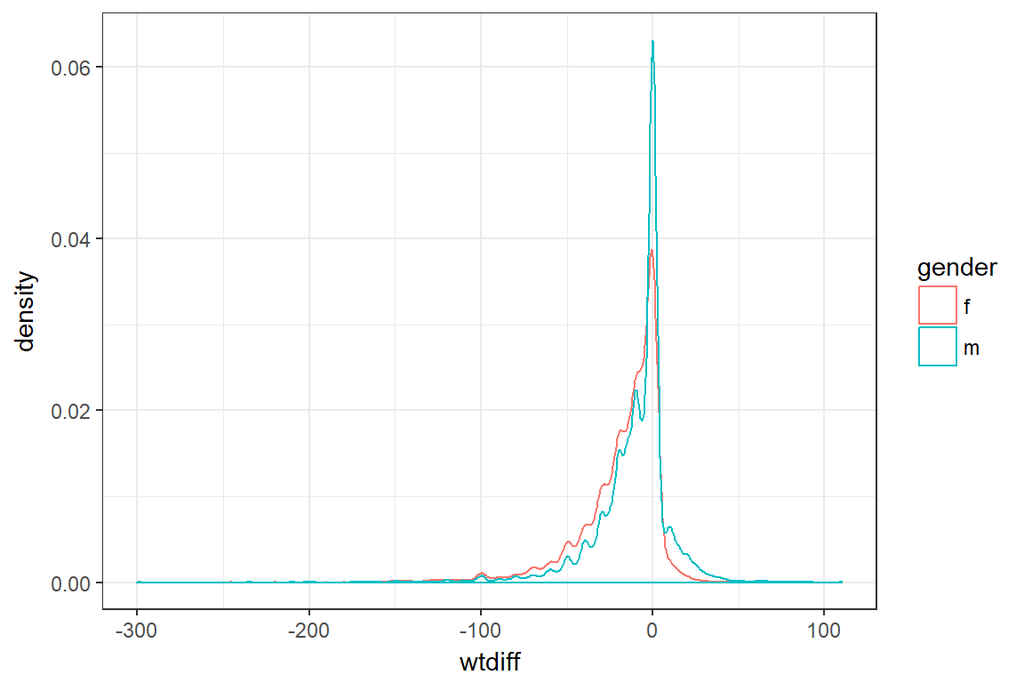

```r
ggplot(cdc, aes(x=wtdiff, col=gender)) + geom_density() + theme_bw()
```

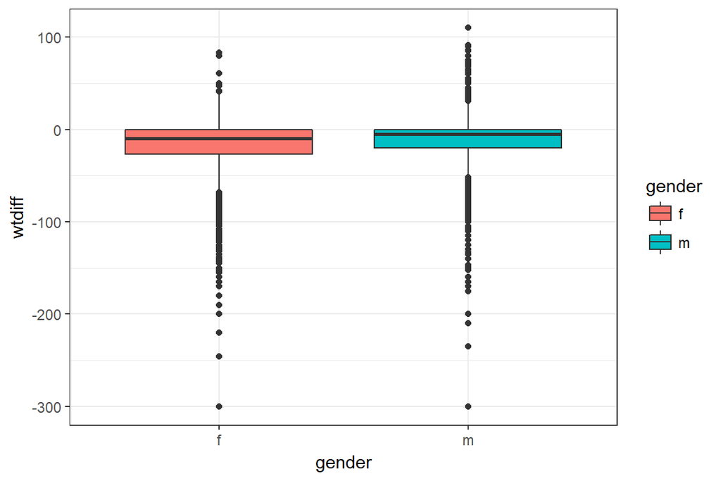

```r
ggplot(cdc, aes(y=wtdiff, x=gender, fill=gender)) + geom_boxplot() + theme_bw()
```

Looks like pretty similar distributions.

2. Use `t.test()` function with **model notation: y ~ x**.

```r
t.test(wtdiff~gender, data=cdc)
```

```
##
##  Welch Two Sample t-test
##
## data:  wtdiff by gender
## t = -22.294, df = 19979, p-value < 2.2e-16
## alternative hypothesis: true difference in means is not equal to 0
## 95 percent confidence interval:
##  -8.004944 -6.711138
## sample estimates:
## mean in group f mean in group m
##       -18.15118       -10.79314
```

On average, males want to loose 10.8 lbs whereas females want to loose 18.2 lbs. We are 95% confident that females on average want to loose 6.7 to 8.0 more lbs compared to males.

### Two sample Z-test for a difference in proportions

**Does a higher proportion of males smoke than females?**

1. Look at the data.

```r
addmargins(table(cdc$smoke100, cdc$gender))
```

```
##
##           f     m   Sum
##   0    6012  4546 10558
##   1    4419  5021  9440
##   Sum 10431  9567 19998
```

```r
prop.table(table(cdc$smoke100, cdc$gender), margin=2)
```

```
##
##             f         m
##   0 0.5763589 0.4751751
##   1 0.4236411 0.5248249
```

42% of females smoke compared to 52% of males.

2. Since `smoke100` is 0/1 numeric, we can still use `t.test()` with model notation.

```r
t.test(smoke100 ~ gender, data=cdc)
```

```
##
##  Welch Two Sample t-test
##
## data:  smoke100 by gender
## t = -14.385, df = 19809, p-value < 2.2e-16
## alternative hypothesis: true difference in means is not equal to 0
## 95 percent confidence interval:
##  -0.11497149 -0.08739621
## sample estimates:
## mean in group f mean in group m
##       0.4236411       0.5248249
```

We could also use `prop.test()` with the frequency table numbers above.

```r
prop.test(x=c(4419, 5021), n=c(10431, 9567))
```

```
##
##  2-sample test for equality of proportions with continuity
##  correction
##
## data:  c(4419, 5021) out of c(10431, 9567)
## X-squared = 204.6, df = 1, p-value < 2.2e-16
## alternative hypothesis: two.sided
## 95 percent confidence interval:
##  -0.11507015 -0.08729755
## sample estimates:
##    prop 1    prop 2
## 0.4236411 0.5248249
```

### ANOVA

**Does the desired weight differ across different general health reporting categories?**

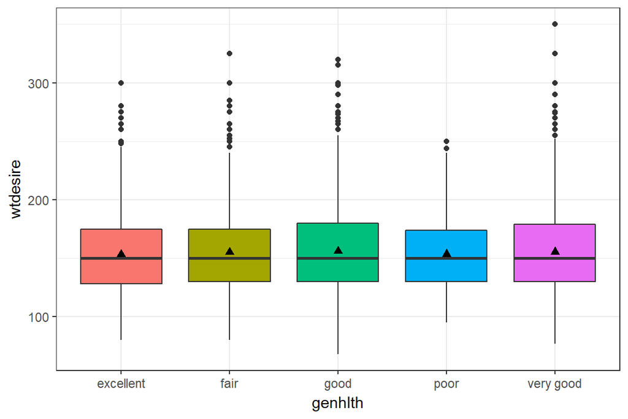

```r
ggplot(cdc, aes(y=wtdesire, x=genhlth, fill=genhlth)) + geom_boxplot() +
        theme_bw() +
        stat_summary(fun.y = "mean", pch=17, geom="point",  size = 2) + # adds the mean as a diamond
        scale_fill_discrete(guide=FALSE) # get rid of the legend created by the fill= argument
```

2. Conduct an ANOVA

```r
model <- aov(wtdesire~genhlth, data=cdc) #aov() is the workhorse function
summary(model) # prints it in an easy to ready fashion.
```

```
##                Df   Sum Sq Mean Sq F value   Pr(>F)
## genhlth         4    21206    5302     5.3 0.000291 ***
## Residuals   19993 20000399    1000
## ---
## Signif. codes:  0 '***' 0.001 '**' 0.01 '*' 0.05 '.' 0.1 ' ' 1
```

At least one group has a different average desired weight (p<.0003).

3. Follow-up with finding out which pairs of groups are different.

```r
TukeyHSD(model)
```

```
##   Tukey multiple comparisons of means
##     95% family-wise confidence level
##
## Fit: aov(formula = wtdesire ~ genhlth, data = cdc)
##
## $genhlth
##                            diff        lwr       upr     p adj
## fair-excellent       1.78916580 -0.5099737 4.0883053 0.2102493
## good-excellent       2.63645738  0.9303678 4.3425470 0.0002422
## poor-excellent       0.08699155 -3.4620206 3.6360037 0.9999955
## very good-excellent  2.08422232  0.4512445 3.7172001 0.0045430
## good-fair            0.84729158 -1.3886656 3.0832487 0.8397624
## poor-fair           -1.70217425 -5.5341776 2.1298291 0.7445592
## very good-fair       0.29505652 -1.8856267 2.4757397 0.9960519
## poor-good           -2.54946583 -6.0578770 0.9589454 0.2745906
## very good-good      -0.55223506 -2.0949854 0.9905153 0.8659094
## very good-poor       1.99723077 -1.4762148 5.4706763 0.5176727
```

The only two groups whose averages differ significantly from each other are:

### Chi-Squared test of

- Association
- Independence
- Goodness of fit
- Equal proportions

### Linear Regression and Correlation

**Is there a linear relationship between how much a person weighs and their desired weight?**

1. Guess what. Yea. Look at your data.

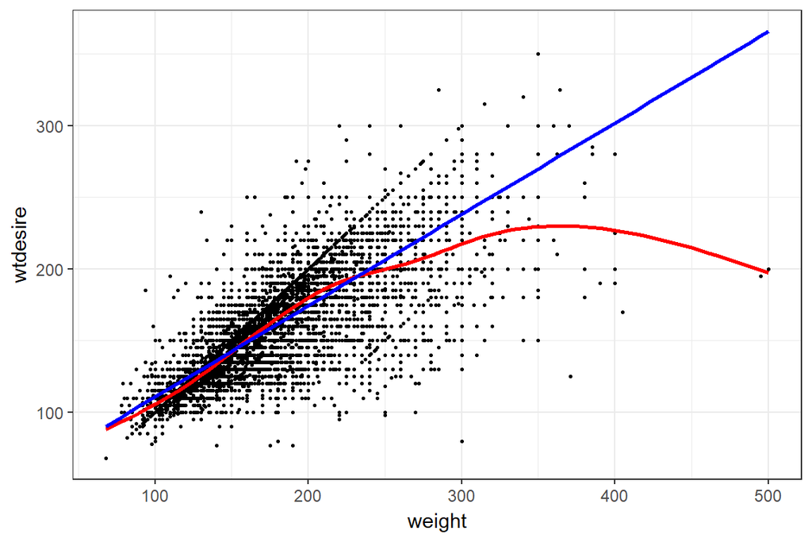

```r
ggplot(cdc, aes(x=weight, y=wtdesire)) +
      geom_point(size=.5) + # lots of points so i'm shrinking the size of the point
      geom_smooth(se=FALSE, col="red") + # adds a smoothing trend line
      geom_smooth(se=FALSE, method="lm", col="blue") + # adds a best fit line
      theme_bw()
```

A linear model may not be appropriate for those who weigh over 250-300 lbs.

2. Fit a linear regression line for those who weigh less than 250 lbs. The workhorse function here is `lm()`, but like `aov()` looks better after being wrapped in a `summary()`.

```r
lt250 <- subset(cdc, weight<=250)

linear.model <- lm(wtdesire ~ weight, data=lt250)
summary(linear.model)
```

```
##
## Call:
## lm(formula = wtdesire ~ weight, data = lt250)
##
## Residuals:
##      Min       1Q   Median       3Q      Max
## -114.963   -8.398    0.804   10.587  112.254
##
## Coefficients:
##             Estimate Std. Error t value Pr(>|t|)
## (Intercept) 35.42780    0.60440   58.62   <2e-16 ***
## weight       0.71014    0.00357  198.89   <2e-16 ***
## ---
## Signif. codes:  0 '***' 0.001 '**' 0.01 '*' 0.05 '.' 0.1 ' ' 1
##
## Residual standard error: 16.95 on 19347 degrees of freedom
## Multiple R-squared:  0.6716, Adjusted R-squared:  0.6715
## F-statistic: 3.956e+04 on 1 and 19347 DF,  p-value: < 2.2e-16
```

The linear regression equation is
$$y = 35.4 + .71x$$
.

Calculate the simple correlation between actual and desired weight.

```r
cor(lt250$wtdesire, lt250$weight)
```

```
## [1] 0.8194856
```

### Multple Linear Regression

You can add multiple predictors to any regression model by adding the variable names using a `+`.

**How does gender affect the relationship between how much a person weighs and their desired weight?**

1. Guess what. Yea. Look at your data.

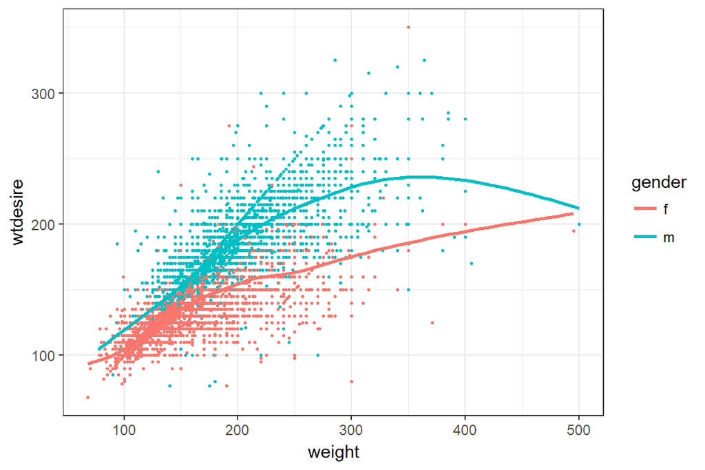

```r
ggplot(cdc, aes(x=weight, y=wtdesire, col=gender)) +
      geom_point(size=.5) +
      geom_smooth(se=FALSE) + # adds a smoothing trend line - per group
      theme_bw()
```

2. Fit the additive linear model of weight + gender

```r
summary(lm(wtdesire ~ weight + gender, data=lt250))
```

```
##
## Call:
## lm(formula = wtdesire ~ weight + gender, data = lt250)
##
## Residuals:
##     Min      1Q  Median      3Q     Max
## -98.320  -6.899   0.154   6.634 119.743
##
## Coefficients:
##              Estimate Std. Error t value Pr(>|t|)
## (Intercept) 53.912757   0.490459   109.9   <2e-16 ***
## weight       0.527835   0.003158   167.1   <2e-16 ***
## genderm     25.087468   0.215985   116.2   <2e-16 ***
## ---
## Signif. codes:  0 '***' 0.001 '**' 0.01 '*' 0.05 '.' 0.1 ' ' 1
##
## Residual standard error: 13.01 on 19346 degrees of freedom
## Multiple R-squared:  0.8065, Adjusted R-squared:  0.8065
## F-statistic: 4.032e+04 on 2 and 19346 DF,  p-value: < 2.2e-16
```

Note the coefficient for gender: `genderm`. R appends the factor level that it is modeling to the end of the variable name, so `gender**m**` means the effect of being male on the relationship between actual and desired weight compared to the reference group (females).

What about an interaction? Does gender *change* the relationship between acutal and desired weight? Interaction terms are added using a `*`.

```r
summary(lm(wtdesire ~ weight + gender + weight*gender, data=lt250))
```

```
##
## Call:
## lm(formula = wtdesire ~ weight + gender + weight * gender, data = lt250)
##
## Residuals:
##      Min       1Q   Median       3Q      Max
## -105.088   -6.416   -0.075    6.419  123.249
##
## Coefficients:
##                 Estimate Std. Error t value Pr(>|t|)
## (Intercept)    66.393808   0.624130 106.378  < 2e-16 ***
## weight          0.444570   0.004079 108.983  < 2e-16 ***
## genderm        -7.755831   1.074991  -7.215  5.6e-13 ***
## weight:genderm  0.194001   0.006227  31.157  < 2e-16 ***
## ---
## Signif. codes:  0 '***' 0.001 '**' 0.01 '*' 0.05 '.' 0.1 ' ' 1
##
## Residual standard error: 12.69 on 19345 degrees of freedom
## Multiple R-squared:  0.8157, Adjusted R-squared:  0.8157
## F-statistic: 2.855e+04 on 3 and 19345 DF,  p-value: < 2.2e-16
```

The interaction term is significant.

# Advanced Analyses

- Non-parametric tests
- Generalized Linear Models
- Time Series
- Factor Analysis & Principle Component Analyses
- Cluster Analysis
  - k-nearest neighbors
  - hierarchical clustering
- Tree-Based Models
  - Decision Trees
  - Random Forests
- Bootstrapping standard errors
- Bayesian analysis using JAGS https://www.amazon.com/Doing-Bayesian-Data-Analysis-Second/dp/0124058884